# Escenarios de desarrollo demográfico de los municipios del cantón de Lucerna

Juan Camilo Bazurto

2023-11-23

## Descripción

Los escenarios de población LUSTAT para el cantón de Lucerna son cálculos de modelos que extrapolan la evolución de la población residente permanente a nivel municipal. Se han calculado tres variantes para cada escenario, que difieren en las hipótesis subyacentes. Tienen en cuenta las hipótesis del modelo basadas en las tendencias demográficas y socioeconómicas de las últimas décadas. El año de cálculo de las ratios en los que se basan los cálculos corresponde al año 2021. La población residente permanente a 31.12.2019 se utiliza como stock inicial para las hipótesis.

# Escenario bajo 2020 - 2050

## Descripción

El escenario bajo se basa en hipótesis que impulsan menos el nivel educativo y el crecimiento económico, reduciendo así el crecimiento de la población en comparación con el escenario de referencia.

## Carga de Datos

Cargamos los datos demográficos del archivo CSV proporcionado.

```r
data <- read.csv("szbv-lu-2020-2050-tief.csv", sep = ";")
head(data)
```

|  | jahr | ktnr | kt | gnr | gemeinde | variante | alter | sex | nation | swb0 | geb | tod | ws | ein | swb |
| --- | --- | --- | --- | --- | --- | --- | --- | --- | --- | --- | --- | --- | --- | --- | --- |
| 1 | 2020 | 3 | LU | 1001 | Doppleschwand | tief | 0 | m | A | 0 | 0.2217614 | -0.001399074 | -0.006202249 | -0.0009376800 | 0.2132224 |
| 2 | 2020 | 3 | LU | 1001 | Doppleschwand | tief | 0 | m | CH | 0 | 3.7603151 | -0.014874283 | -0.055545566 | 0.0009376802 | 3.6908329 |
| 3 | 2020 | 3 | LU | 1001 | Doppleschwand | tief | 0 | w | A | 0 | 0.2112013 | -0.000944102 | -0.009848692 | -0.0065561380 | 0.1938524 |
| 4 | 2020 | 3 | LU | 1001 | Doppleschwand | tief | 0 | w | CH | 0 | 3.5812524 | -0.008462092 | -0.000133810 | 0.0065561381 | 3.5792127 |
| 5 | 2020 | 3 | LU | 1001 | Doppleschwand | tief | 1 | m | A | 1 | 0.0000000 | 0.000000000 | -0.002159653 | -0.0129589630 | 0.9848814 |
| 6 | 2020 | 3 | LU | 1001 | Doppleschwand | tief | 1 | m | CH | 7 | 0.0000000 | -0.004016119 | -0.013712926 | 0.0129589633 | 6.9952299 |

## Análisis Exploratorio de Datos (EDA)

Realizamos un resumen estadístico y contamos los datos faltantes.

```r
# Resumen estadístico de data
summary(data)
```

```
##       jahr           ktnr        kt                 gnr
##  Min.   :2020   Min.   :3   Length:1001920     Min.   :1001
##  1st Qu.:2027   1st Qu.:3   Class :character   1st Qu.:1041
##  Median :2035   Median :3   Mode  :character   Median :1082
##  Mean   :2035   Mean   :3                      Mean   :1078
##  3rd Qu.:2043   3rd Qu.:3                      3rd Qu.:1121
##  Max.   :2050   Max.   :3                      Max.   :1151
##    gemeinde           variante             alter         sex
##  Length:1001920     Length:1001920     Min.   :  0   Length:1001920
##  Class :character   Class :character   1st Qu.: 25   Class :character
##  Mode  :character   Mode  :character   Median : 50   Mode  :character
##                                        Mean   : 50
##                                        3rd Qu.: 75
##                                        Max.   :100
##     nation               swb0               geb                tod
##  Length:1001920     Min.   :  0.0000   Min.   :  0.0000   Min.   :-33.10743
##  Class :character   1st Qu.:  0.9533   1st Qu.:  0.0000   1st Qu.: -0.04377
##  Mode  :character   Median :  4.8364   Median :  0.0000   Median : -0.00550
##                     Mean   : 13.6673   Mean   :  0.1237   Mean   : -0.12104
##                     3rd Qu.: 13.9593   3rd Qu.:  0.0000   3rd Qu.:  0.00000
##                     Max.   :733.0568   Max.   :401.4931   Max.   :  0.00000
##        ws                 ein                swb
##  Min.   :-90.15518   Min.   :-7.59494   Min.   :  0.0000
##  1st Qu.: -0.01063   1st Qu.:-0.01203   1st Qu.:  0.9574
##  Median :  0.00000   Median : 0.00000   Median :  4.8567
##  Mean   :  0.03493   Mean   : 0.00000   Mean   : 13.7049
##  3rd Qu.:  0.02111   3rd Qu.: 0.01203   3rd Qu.: 13.9861
##  Max.   : 24.43887   Max.   : 7.59494   Max.   :733.0568
```

```r
# Contar datos faltantes por variable
sum(is.na(data))
```

```
## [1] 0
```

## Visualización de Distribuciones

Generamos histogramas para nacimientos, muertes y la distribución de la población total.

### Distribución de Nacimientos (geb):

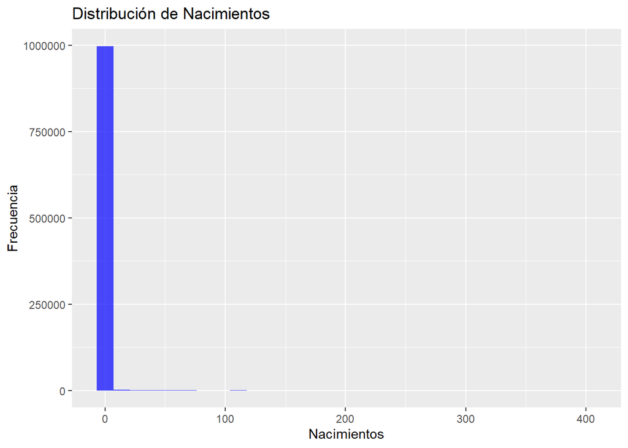

Esta gráfica muestra una concentración extrema de los datos en el extremo inferior de nacimientos, lo que sugiere que hay una gran cantidad de áreas con tasas de nacimiento muy bajas. La presencia de barras altas cerca del valor cero podría indicar poblaciones pequeñas o tasas de natalidad bajas en la mayoría de las áreas.

### Distribución de Muertes (tod):

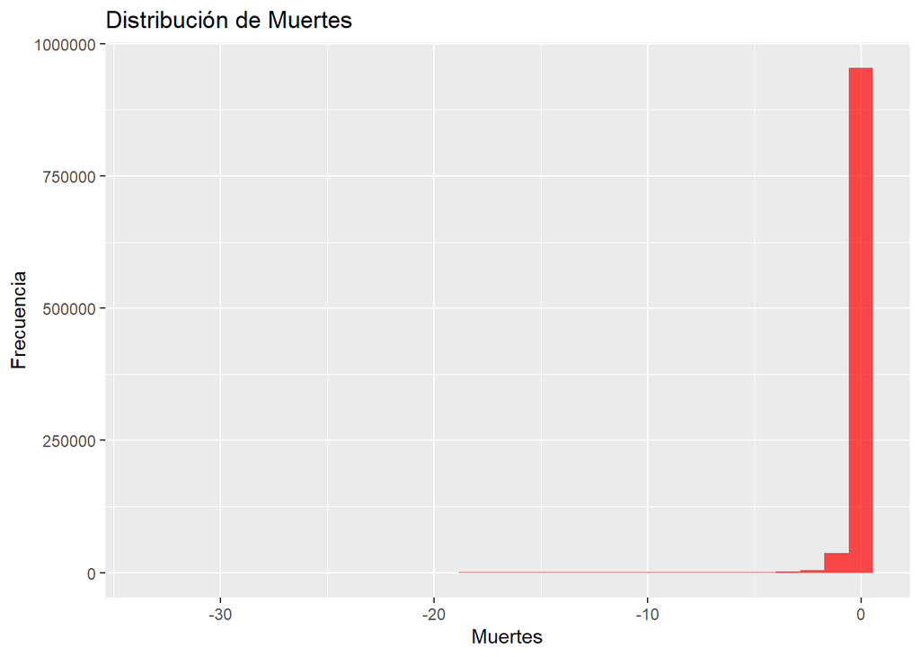

Esta grafica representa las muertes, muestra una anomalía con valores negativos, lo cual no es posible en términos reales.

### Distribución de la Población Total (swb):

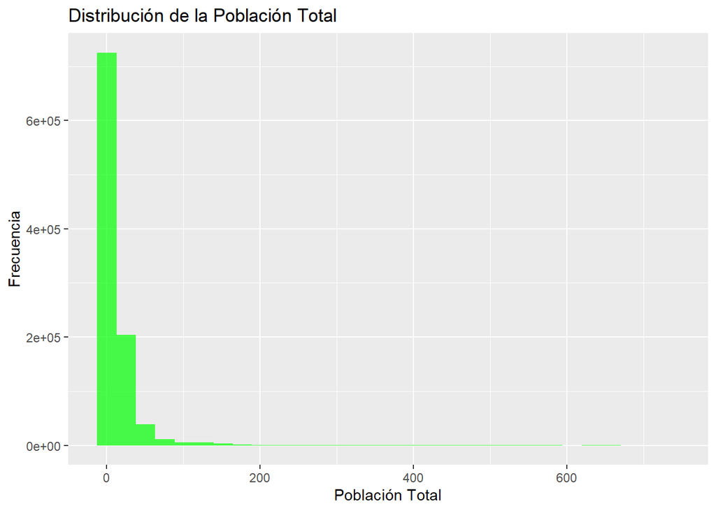

Esta gráfica muestra que la mayoría de los valores de población están concentrados en el extremo inferior, lo que indica que la mayoría de los municipios tienen poblaciones pequeñas, mientras que unos pocos tienen poblaciones mucho más grandes.

### Distribución por Edad (alter):

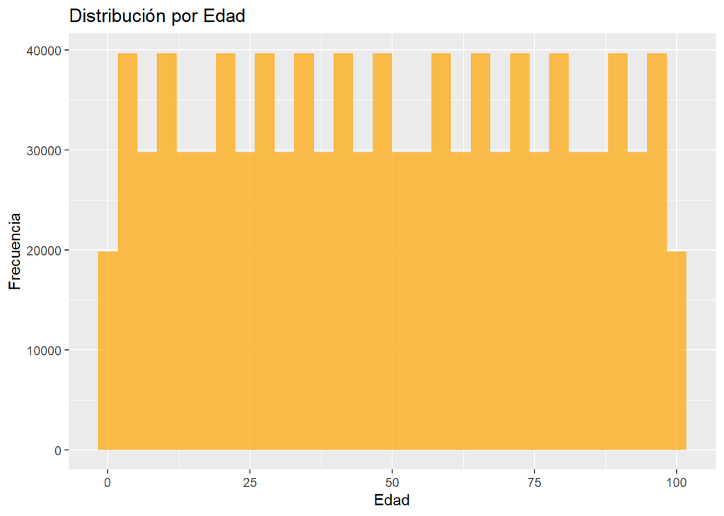

Esta gráfica muestra una distribución uniforme de la población por edades, con barras relativamente iguales a través de todas las edades. Esto puede sugerir que la población está distribuida de manera uniforme entre diferentes grupos de edad.

## Análisis Multivariado

Evaluamos correlaciones y generamos gráficos de dispersión.

```
##                jahr ktnr           gnr         alter        swb0          geb
## jahr   1.000000e+00   NA  1.152898e-21  0.000000e+00  0.01056684 -0.002816062
## ktnr             NA    1            NA            NA          NA           NA
## gnr    1.152898e-21   NA  1.000000e+00  0.000000e+00 -0.08024878 -0.007785901
## alter  0.000000e+00   NA  0.000000e+00  1.000000e+00 -0.06765557 -0.070454960
## swb0   1.056684e-02   NA -8.024878e-02 -6.765557e-02  1.00000000 -0.016591430
## geb   -2.816062e-03   NA -7.785901e-03 -7.045496e-02 -0.01659143  1.000000000
## tod   -2.238651e-02   NA  4.427733e-02 -2.258406e-01 -0.29307069 -0.005117440
## ws    -3.295219e-02   NA -6.432573e-03 -1.177242e-01  0.03054854 -0.035032867
## ein   -5.900345e-13   NA  5.073747e-13  2.491134e-13  0.31429603  0.033798952
## swb    9.502086e-03   NA -8.019271e-02 -7.937246e-02  0.99581819  0.072122246
##               tod           ws           ein          swb
## jahr  -0.02238651 -0.032952194 -5.900345e-13  0.009502086
## ktnr           NA           NA            NA           NA
## gnr    0.04427733 -0.006432573  5.073747e-13 -0.080192711
## alter -0.22584057 -0.117724222  2.491134e-13 -0.079372459
## swb0  -0.29307069  0.030548536  3.142960e-01  0.995818187
## geb   -0.00511744 -0.035032867  3.379895e-02  0.072122246
## tod    1.00000000  0.035871119 -1.766646e-02 -0.275287175
## ws     0.03587112  1.000000000 -2.954380e-01  0.038034894
## ein   -0.01766646 -0.295438036  1.000000e+00  0.321542242
## swb   -0.27528717  0.038034894  3.215422e-01  1.000000000
```

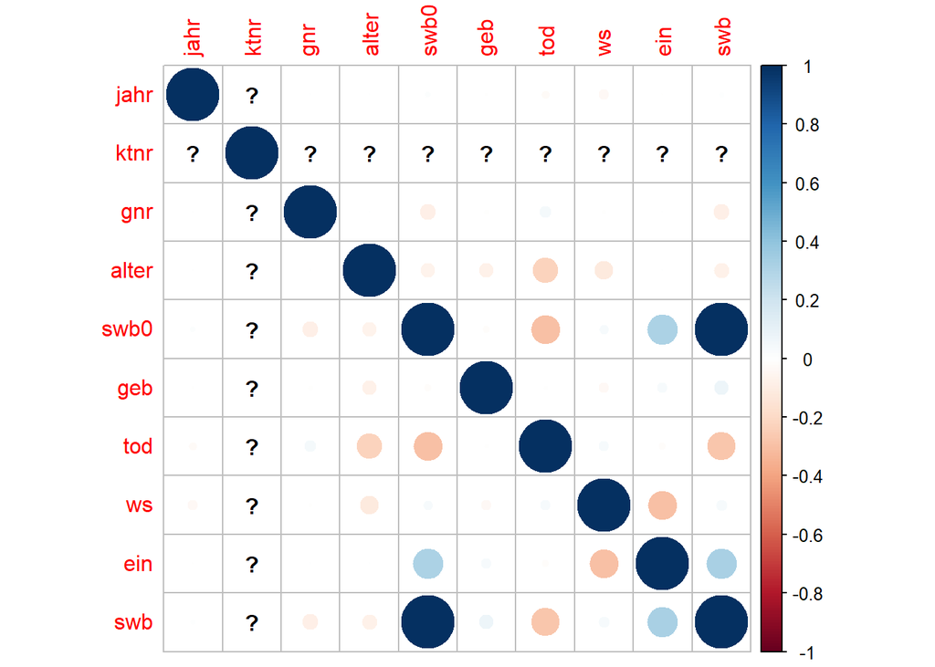

Las correlaciones entre jahr (año) y las demás variables son cercanas a cero, lo que indica que no hay una relación lineal entre el tiempo y las demás variables demográficas. La correlación entre swb0 (población al comienzo del año) y swb (población al final del año) es muy alta (aproximadamente 0.996), lo que es esperable ya que son mediciones de población en diferentes momentos. ein (inmigración durante el año) tiene una correlación moderada con swb0 y swb, lo que sugiere que la inmigración tiene un impacto medible en la población. Las correlaciones entre ws (movimientos espaciales) y otras variables son generalmente bajas, aunque hay una correlación negativa moderada con ein, posiblemente indicando que los movimientos espaciales y la inmigración pueden ser fenómenos opuestos o que se regulan mutuamente. Las correlaciones entre tod (muertes) y alter (edad) son negativas y moderadas, lo que podría reflejar que las muertes se registran de manera más frecuente en edades avanzadas.

### Población al Final del Año vs Inmigración:

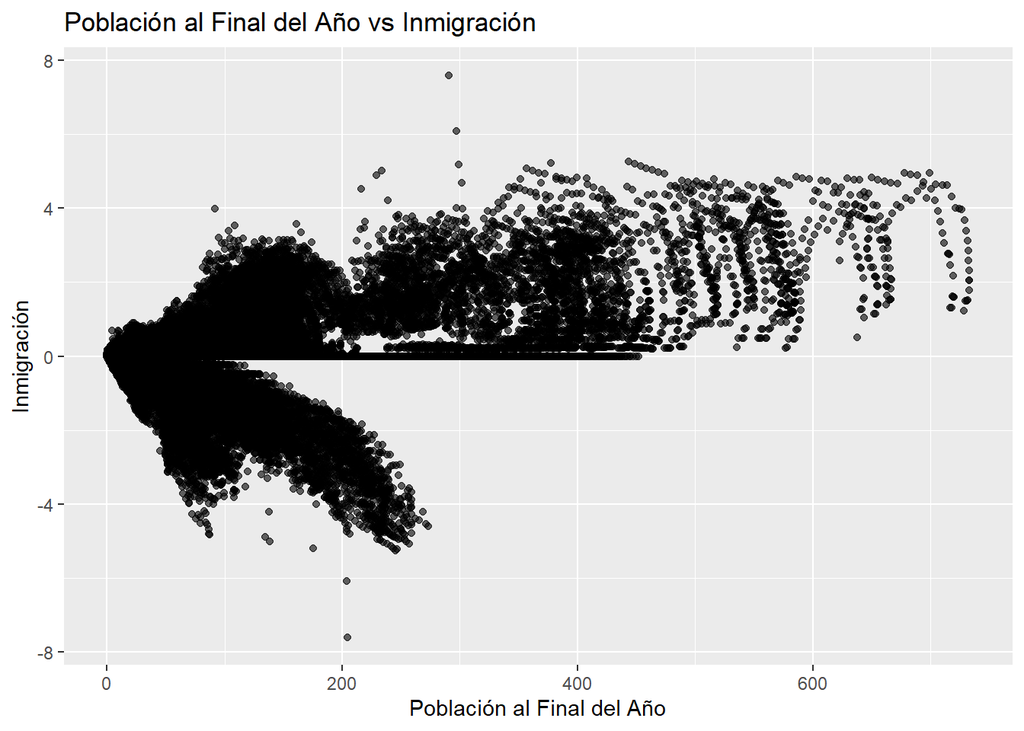

El diagrama de dispersión muestra una amplia dispersión de puntos, lo que indica una variabilidad significativa en la relación entre la población al final del año y la inmigración. No parece haber una correlación clara, lo que sugiere que la inmigración no es el único factor que influye en la población al final del año.

### Población al Final del Año vs Cambio por Movimientos Espaciales:

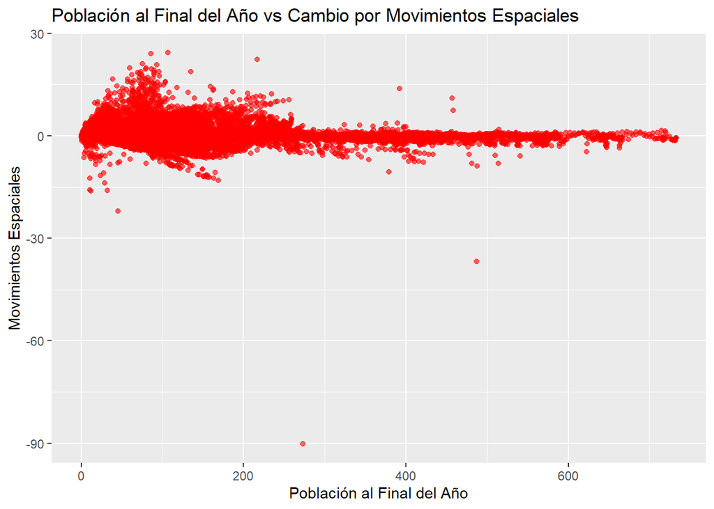

Esta gráfica muestra una tendencia dispersa con algunos puntos alejados de la mayoría, lo que indica algunos casos con cambios significativos en la población debido a movimientos espaciales. La mayoría de los puntos están concentrados horizontalmente, indicando que, para la mayoría de las áreas, los movimientos espaciales no tienen un gran impacto en la población al final del año.

### Gráfico de Dispersión (nacimientos vs. movimientos espaciales):

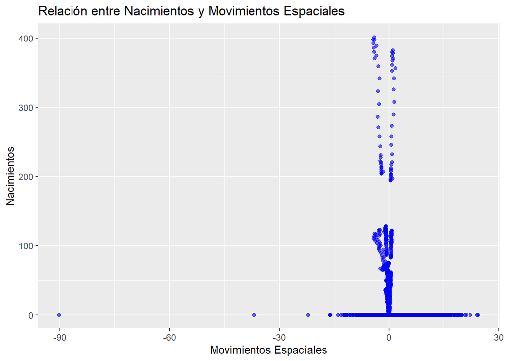

Esta gráfica muestra una concentración de puntos a lo largo del eje de los movimientos espaciales en cero, con varios valores atípicos, especialmente en la dirección negativa. Existe una agrupación de valores altos de nacimientos que no parecen tener una correspondencia clara con los movimientos espaciales, lo que indica que los nacimientos altos no están necesariamente vinculados con los movimientos espaciales significativos.

## Análisis de Componentes Principales (PCA)

Realizamos PCA para reducir la dimensionalidad y agrupar los municipios.

### Gráfico del PCA de Variables:

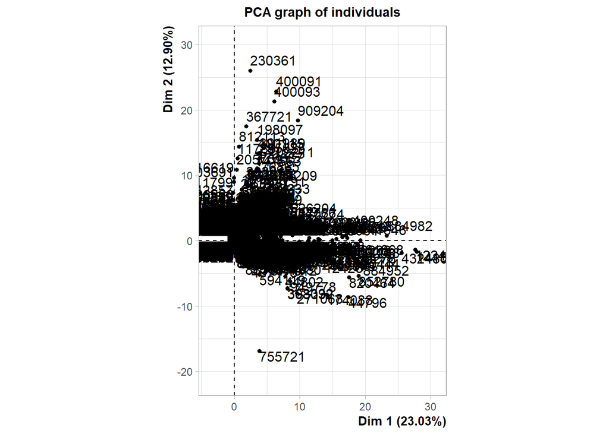

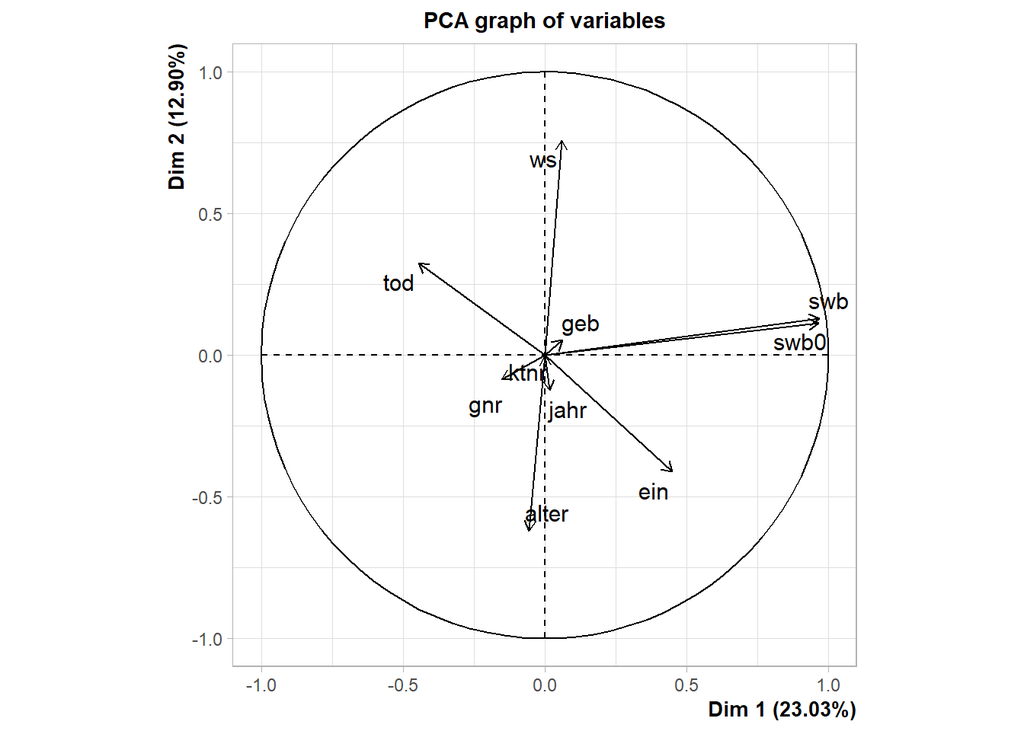

### Scree Plot (Gráfico de Varianza Explicada):

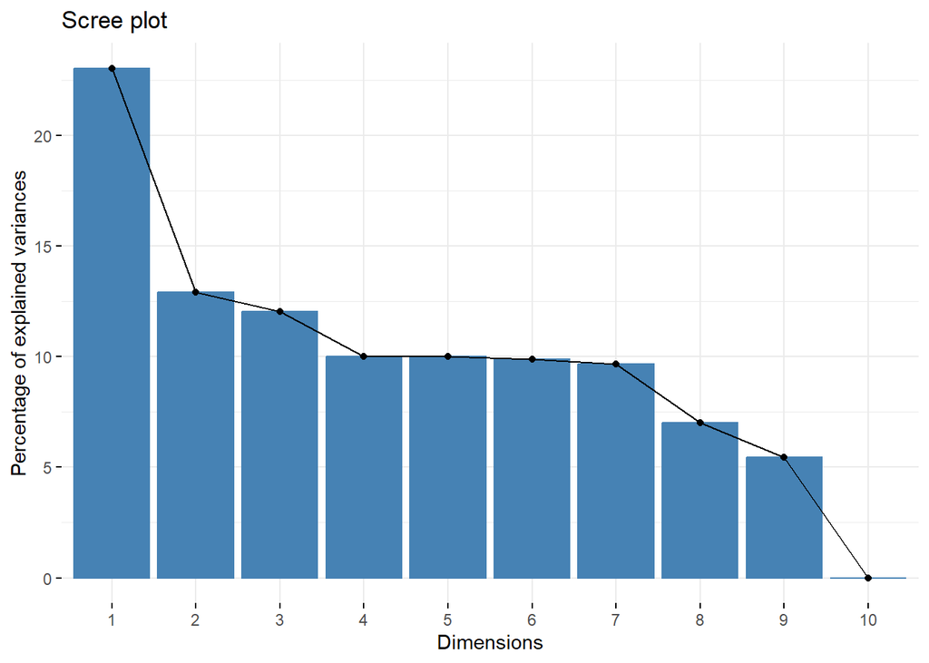

[figure not shown]

### PCA - Biplot:

El biplot muestra la relación entre las variables y los individuos en el espacio de los dos primeros componentes principales. Parece haber una gran dispersión de los individuos, lo que indica diversidad en las características demográficas dentro del conjunto de datos.

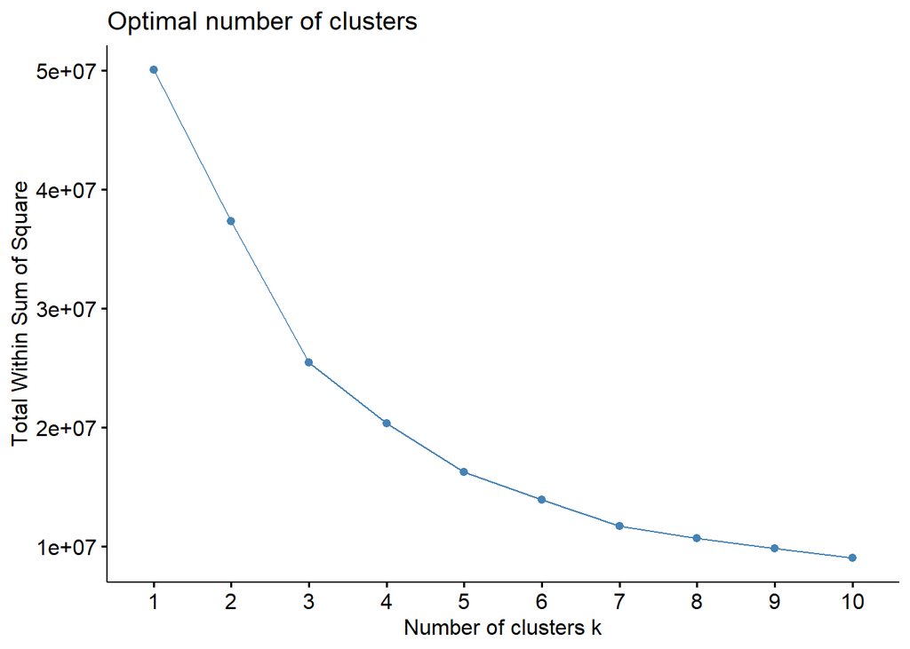

### Gráfico del Número Óptimo de Clusters:

El método del codo sugiere que hay un punto de inflexión en el gráfico, lo que podría usarse para determinar el número óptimo de clusters. No hay un ‘codo’ muy definido, pero se podria elegir un número de clusters basado en el punto donde la disminución en la suma de cuadrados dentro del grupo se estabiliza.

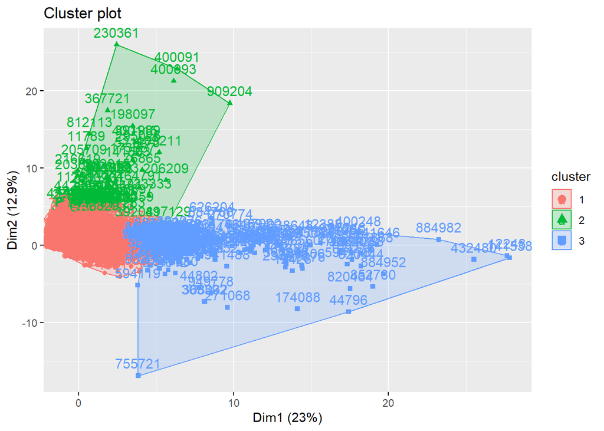